# Exploring bee-related spatial data

Piyush Amitabh

# Conservation/ecology Topics

> - Species distributions

# Computational Topics

# Oregon bee atlas data exploration

Import the OBA data from 2018 and 2019 what you favorite parsing function (in the data folder of this lab’s zip, converted to a .csv)

# Excersize 1.1

```r
getwd()
```

```
## [1] "/home/piyush/Dropbox/Academics/BI510L Data Sci in R/BI510L Data Sci in R_code/bi510l_project"
```

```r
setwd("/home/piyush/Dropbox/Academics/BI510L Data Sci in R/BI510L Data Sci in R_code/bi510l_project")
oba_2018 <- read.csv("data/2018_occurrence.csv")
oba_2019 <- read.csv("./data/2019_occurrence.csv")
# colnames(oba_2018)
```

# Excersize 1.2

It will be cumbersome to deal with each dataframe individually. Are the column names in the identical order such that you could use `rbind()` (row bind) to bind them together? Some combination of the functions `colnames()`, `identical()`

```r
cat("The colnames are identical:", identical(colnames(oba_2018), colnames(oba_2019)))
```

```
## The colnames are identical: TRUE
```

```r
oba_2018_2019 <- rbind(oba_2018, oba_2019)
```

# Excersize 1.3

Find the column related to a specimens species ID. Use `sort()` and `unique()` to print the unique values in alphabetical order. How many species are there?

```r
# colnames(oba_2018_2019)
species_list <- oba_2018_2019 %>%
  filter(species != "", !is.na(species)) %>%
  pull(species) %>%
  unique() %>%
  sort()
sample(species_list, 10)
```

```
##  [1] "Atoposmia oregona"     "Osmia enixa"           "Ashmeadiella cubiceps"
##  [4] "Andrena prunorum"      "Anthidium illustre"    "Megachile mellitarsis"
##  [7] "Hoplitis louisae"      "Osmia rostrata"        "Megachile relativa"
## [10] "Megachile melanophaea"
```

```r
length(species_list)
```

```
## [1] 269
```

Some specimens are not identified to species, only genus. How is this reflected in the data?

# Excersize 1.4

So many bees, so little time. Count up the occurrences of each bee species, and subset the data to bees that have been seen at least two times. You can use the tidyverse or any other functions in R that you like. How many species are there?

```r
occurrence_counts <- oba_2018_2019 %>%
  filter(species != "", !is.na(species)) %>%
  group_by(species) %>%
  summarise(count = n()) %>%
  filter(count >= 2)

num_species <- nrow(occurrence_counts)
num_species
```

```
## [1] 240
```

Google a few bee names (that have been seen > 2 times) and find one with an a look that resonates with you.

What is the name of your bee?

```r
set.seed(123) # Add this line to set a seed for the sample function
occurrence_counts[sample(nrow(occurrence_counts), 1), ]
```

```
## # A tibble: 1 × 2
##   species           count
##   <chr>             <int>
## 1 Megachile fidelis    77
```

Megachile fidelis: cute bee with pollen all over!

Import the photos into Rmarkdown below (hint: googling bee name “discover life” or “inat” can often get you a photo. Many bees will no have any photos :(

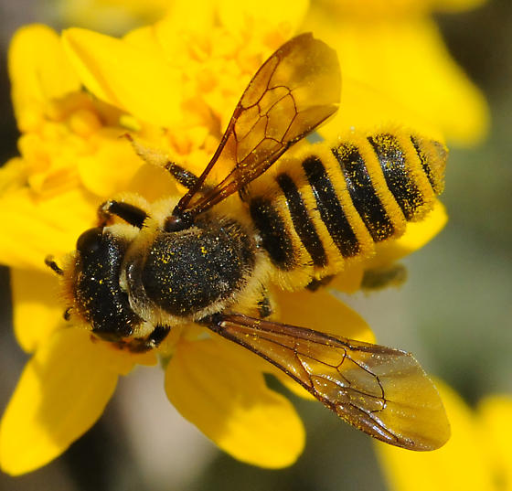

# Excersize 2.1

How that have chosen your spirit bee, we would like to plot it’s distribution. What is the crs of the data? Hint: it is the same as what inat uses because all bees have a georeferenced plant host. If the data is in lat long, it is “unprojected” so only a datum will be listed.

```r
unique(oba_2018_2019$issue)
```

```
## [1] "GEODETIC_DATUM_ASSUMED_WGS84;CONTINENT_DERIVED_FROM_COORDINATES;COLLECTION_MATCH_NONE"
## [2] "COORDINATE_ROUNDED;GEODETIC_DATUM_ASSUMED_WGS84;CONTINENT_DERIVED_FROM_COORDINATES;COLLECTION_MATCH_NONE"
## [3] "GEODETIC_DATUM_ASSUMED_WGS84;CONTINENT_DERIVED_FROM_COORDINATES;TAXON_MATCH_FUZZY;COLLECTION_MATCH_NONE"
## [4] "COORDINATE_ROUNDED;GEODETIC_DATUM_ASSUMED_WGS84;CONTINENT_DERIVED_FROM_COORDINATES;RECORDED_DATE_INVALID;COLLECTION_MATCH_NONE"
## [5] "COORDINATE_INVALID;COLLECTION_MATCH_NONE"
## [6] "GEODETIC_DATUM_ASSUMED_WGS84;CONTINENT_DERIVED_FROM_COORDINATES"
## [7] "GEODETIC_DATUM_ASSUMED_WGS84;CONTINENT_DERIVED_FROM_COORDINATES;TAXON_MATCH_FUZZY"
```

# Excersize 2.2.

Extract the X and Y locations for your species only from the data and create a spatial object. Don’t forget to set the CRS! Hint 1: consider what other data you would like to keep as attributes, for example what flower they were foraging on. Hint 2: Remember the lat is y and long is x.

```r
spirit_bee <- "Megachile fidelis"
species_data <- oba_2018_2019 %>%
  filter(species == spirit_bee) %>%
  select(x = decimalLongitude, y = decimalLatitude, associatedTaxa)
head(species_data)
```

```
##           x       y                                  associatedTaxa
## 1 -123.2950 42.2133               "foraging on" : "Solidago rigida"
## 2 -120.1159 44.3673
## 3 -123.0945 44.0328                         "foraging on" : "Aster"
## 4 -123.2950 42.2133 "foraging on" : "Symphyotrichum oolentangiense"
## 5 -123.3159 44.5988
## 6 -122.1197 42.4472           "foraging on" : "Senecio hydrophilus"
```

```r
species_data <- species_data %>%
  mutate(associatedTaxa = str_split(associatedTaxa, ":", simplify = TRUE)[, 2]) %>%
  mutate(associatedTaxa = replace(associatedTaxa, associatedTaxa == "", "no associated plant"))
head(species_data)
```

```
##           x       y                   associatedTaxa
## 1 -123.2950 42.2133                "Solidago rigida"
## 2 -120.1159 44.3673              no associated plant
## 3 -123.0945 44.0328                          "Aster"
## 4 -123.2950 42.2133  "Symphyotrichum oolentangiense"
## 5 -123.3159 44.5988              no associated plant
## 6 -122.1197 42.4472            "Senecio hydrophilus"
```

```r
species_spatial <- st_as_sf(species_data, coords = c("x", "y"), crs = "WGS84")
(species_spatial)
```

```
## Simple feature collection with 77 features and 1 field
## Geometry type: POINT
## Dimension:     XY
## Bounding box:  xmin: -123.413 ymin: 42.013 xmax: -118.7788 ymax: 45.702
## Geodetic CRS:  WGS 84
## First 10 features:
##                      associatedTaxa                  geometry
## 1                 "Solidago rigida"  POINT (-123.295 42.2133)
## 2               no associated plant POINT (-120.1159 44.3673)
## 3                           "Aster" POINT (-123.0945 44.0328)
## 4   "Symphyotrichum oolentangiense"  POINT (-123.295 42.2133)
## 5               no associated plant POINT (-123.3159 44.5988)
## 6             "Senecio hydrophilus" POINT (-122.1197 42.4472)
## 7      "Chamaenerion angustifolium" POINT (-118.7788 44.2386)
## 8                           "Aster" POINT (-123.0945 44.0328)
## 9                 "Solidago rigida"  POINT (-123.295 42.2133)
## 10              no associated plant POINT (-123.2461 44.6292)
```

# Excersize 2.3

Plot your exciting bee data!

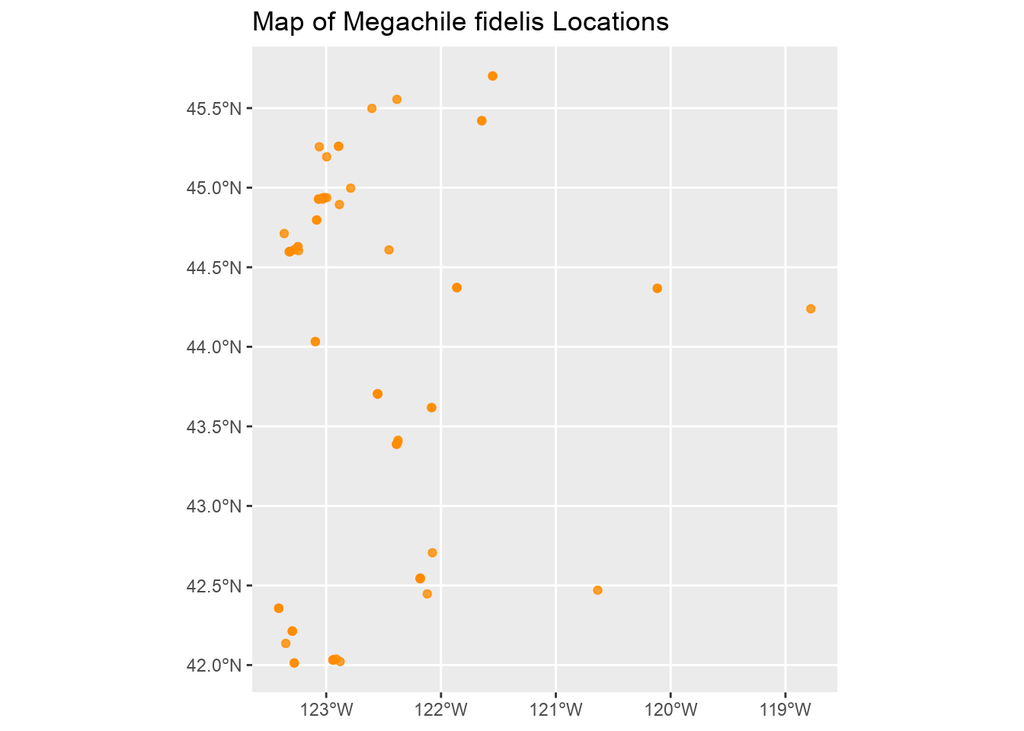

```r
# doesn't run in vscode, knit in rstudio for final submission
ggplot() +
  geom_sf(data = species_spatial, color = "darkorange", alpha = 0.8) +
  ggtitle(glue("Map of {spirit_bee} Locations"))
```

Not so exciting without some kind of background…

# Excersize 2.4

Luckily we can download basemaps into R using the map_data function in ggplot (amoung many others). There is an example for retrieving the Oregon county polygons.

```r
# get Oregon map
or_map_base_df <- map_data("state") %>%
  filter(region == "oregon") %>%
  select(longitude = long, latitude = lat, group_id = group, state_name = region)
str(or_map_base_df)
```

```
## 'data.frame':    236 obs. of  4 variables:
##  $ longitude : num  -117 -117 -117 -117 -117 ...
##  $ latitude  : num  46 46 45.9 45.9 45.9 ...
##  $ group_id  : num  44 44 44 44 44 44 44 44 44 44 ...
##  $ state_name: chr  "oregon" "oregon" "oregon" "oregon" ...
```

```r
or_map_county_df <- map_data("county", "oregon") %>%
  select(longitude = long, latitude = lat, group_id = group, county_name = subregion)
str(or_map_county_df)
```

```
## 'data.frame':    1633 obs. of  4 variables:
##  $ longitude  : num  -117 -117 -117 -118 -118 ...
##  $ latitude   : num  44.3 44.3 44.4 44.4 44.4 ...
##  $ group_id   : num  1 1 1 1 1 1 1 1 1 1 ...
##  $ county_name: chr  "baker" "baker" "baker" "baker" ...
```

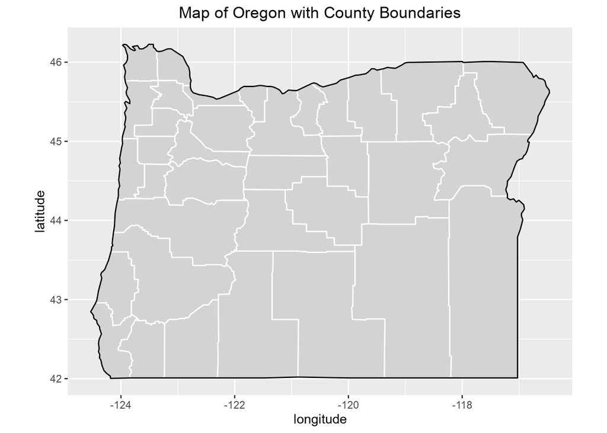

```r
# plot Oregon map with bee location overlaid
plot_or_w_county <- ggplot() +
  geom_polygon(
    data = or_map_county_df, fill = "lightgray", color = "white",
    aes(x = longitude, y = latitude, group = county_name)
  ) +
  geom_polygon(
    data = or_map_base_df, fill = NA, color = "black",
    aes(x = longitude, y = latitude, group = state_name)
  ) +
  theme(plot.title = element_text(hjust = 0.5))
plot_or_w_county +
  ggtitle(glue("Map of Oregon with County Boundaries")) +
  coord_quickmap()
```

Add your species’s points to your choice or an Oregon basemap.

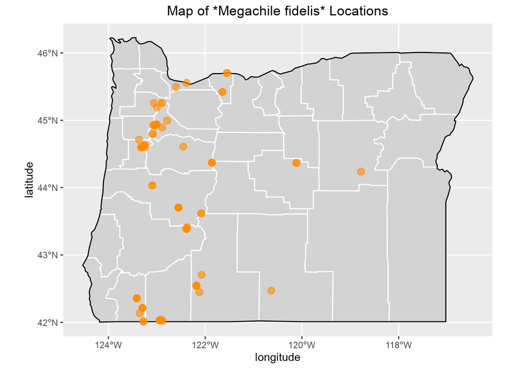

```r
# plot oregon map with bee location overlaid
plot_or_w_county +
  geom_sf(data = species_spatial, color = "darkorange", alpha = 0.6, size = 3) +
  ggtitle(glue("Map of *{spirit_bee}* Locations"))
```

# Excersize 2.5

Here is your moment to explore your cartographic skills.

- 1. Add another spatial layer relevant to your final project and tweak the Oregon map in anyway that is useful/visually appealing. You may need to crop that layer to the extent of your species’s distribution. DONE
- 2. Color your points according to some data attribute and add a legend (month collected, county, collector, associated plant, whatever you think is interesting). You may need to circle back to 2.1 to save additional attributes when you converted the data frame to a spatial object. DONE
- 3. Fine-tune your map: add a title, make sure the legend label makes sense, add a scale bar (google “add scale bar map ggplot” and choose your favorite package). All maps must always have a scale bar. You can add a N arrow as well, though some cartographers argue that is only necessary if N isn’t at the top of the map. TODO
- 4. Write a figure caption for your map explaining any interesting trends you see. DONE
- 5. Export you cropped layer to a .shp so you can use it again for your final project. Not applicable
- 6. Push this lab to your github repo (just the .Rmd, don’t push the data!) DONE

```r
# data taken from https://www.oregon-demographics.com/counties_by_population

# make a data frame
or_dem <- readxl::read_xlsx("./data/oregon_demographics_by_county.xlsx", skip = 4, col_names = TRUE)
head(or_dem)
```

```
## # A tibble: 6 × 67
##   name  state county city  most_current_pop_year population pop_dens_sq_mi  mhhi
##   <chr> <chr> <lgl>  <lgl>                 <dbl>      <dbl>          <dbl> <dbl>
## 1 Oreg… Oreg… NA     NA                     2022    4229374           44.1 76632
## 2 Bake… Oreg… NA     NA                     2022      16685            5.4 51657
## 3 Bent… Oreg… NA     NA                     2022      95615          142.  72882
## 4 Clac… Oreg… NA     NA                     2022     420925          225   95740
## 5 Clat… Oreg… NA     NA                     2022      41190           NA      NA
## 6 Colu… Oreg… NA     NA                     2022      52865           NA      NA
## # ℹ 59 more variables: hhi_total_hh <dbl>, hhi_hh_w_lt_25k <dbl>,
## #   hhi_hh_w_25k_49k <dbl>, hhi_hh_w_50k_74k <dbl>, hhi_hh_w_75k_99k <dbl>,
## #   hhi_hh_w_100k_149k <dbl>, hhi_hh_w_150k_199k <dbl>,
## #   hhi_hh_w_200k_plus <dbl>, race_ethnicity_total <dbl>,
## #   race_ethnicity_white <dbl>, race_ethnicity_black <dbl>,
## #   race_ethnicity_native <dbl>, race_ethnicity_asian <dbl>,
## #   race_ethnicity_islander <dbl>, race_ethnicity_other <dbl>, …
```

```r
colnames(or_dem)
```

```
##  [1] "name"                              "state"
##  [3] "county"                            "city"
##  [5] "most_current_pop_year"             "population"
##  [7] "pop_dens_sq_mi"                    "mhhi"
##  [9] "hhi_total_hh"                      "hhi_hh_w_lt_25k"
## [11] "hhi_hh_w_25k_49k"                  "hhi_hh_w_50k_74k"
## [13] "hhi_hh_w_75k_99k"                  "hhi_hh_w_100k_149k"
## [15] "hhi_hh_w_150k_199k"                "hhi_hh_w_200k_plus"
## [17] "race_ethnicity_total"              "race_ethnicity_white"
## [19] "race_ethnicity_black"              "race_ethnicity_native"
## [21] "race_ethnicity_asian"              "race_ethnicity_islander"
## [23] "race_ethnicity_other"              "race_ethnicity_two"
## [25] "race_ethnicity_hispanic"           "age_total"
## [27] "age_f_0_9"                         "age_f_10_19"
## [29] "age_f_20_29"                       "age_f_30_39"
```

[output cut: 19 more lines]

```r
# select only two columns, remove oregon total population, add 'county' col, convert everything to lowercase
or_pop_by_county_df <- or_dem %>%
  select(name, population) %>%
  filter(name != "Oregon") %>%
  mutate(county_name = tolower(str_replace(name, " County$", ""))) %>%
  select(-name)

head(or_pop_by_county_df)
```

```
## # A tibble: 6 × 2
##   population county_name
##        <dbl> <chr>
## 1      16685 baker
## 2      95615 benton
## 3     420925 clackamas
## 4      41190 clatsop
## 5      52865 columbia
## 6      64908 coos
```

```r
head(or_map_county_df)
```

```
##   longitude latitude group_id county_name
## 1 -117.2042 44.30683        1       baker
## 2 -117.4907 44.30683        1       baker
## 3 -117.4907 44.38704        1       baker
## 4 -117.5366 44.42142        1       baker
## 5 -117.5709 44.42142        1       baker
## 6 -117.5996 44.43861        1       baker
```

```r
# now the county_name in or_pop_by_county_df corresponds to or_map_county_df, join them in a single df
or_map_with_population_df <- left_join(or_map_county_df, or_pop_by_county_df, by = "county_name")
head(or_map_with_population_df)
```

```
##   longitude latitude group_id county_name population
## 1 -117.2042 44.30683        1       baker      16685
## 2 -117.4907 44.30683        1       baker      16685
## 3 -117.4907 44.38704        1       baker      16685
## 4 -117.5366 44.42142        1       baker      16685
## 5 -117.5709 44.42142        1       baker      16685
## 6 -117.5996 44.43861        1       baker      16685
```

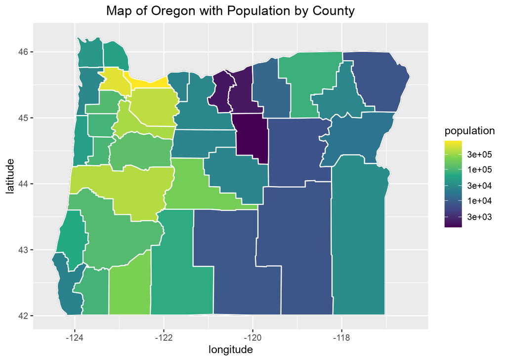

```r
plot_or_w_county +
  ggtitle(glue("Map of Oregon with Population by County")) +
  geom_polygon(data = or_map_with_population_df,
  aes(x = longitude, y = latitude, fill = population, group = county_name), color = "white") +
  scale_fill_continuous(trans = "log10", type = "viridis")
```

```r
coord_sf(datum = sf::st_crs(4326))
```

[output not shown]

[figure not shown]

```r
ggplot() +
  geom_polygon(
    data = or_map_county_df, fill = "lightgray", color = "white",
    aes(x = longitude, y = latitude, group = county_name)
  ) +
  geom_polygon(
    data = or_map_with_population_df,
    aes(x = longitude, y = latitude, fill = population, group = county_name), color = "white"
  ) +
  scale_fill_gradient(trans = "log10", low = "antiquewhite1", high = "antiquewhite4") +
  # scale_fill_gradient(trans = "log10", low = "wheat1", high = "wheat4") +
  # scale_fill_gradient(trans = "log10", low = "azure", high = "azure4") +
  geom_polygon(
    data = or_map_base_df, fill = NA, color = "black",
    aes(x = longitude, y = latitude, group = state_name)
  ) +
  geom_sf(data = species_spatial, aes(color = associatedTaxa), alpha = 0.6, size = 3) +
  geom_segment(aes(x = -118.4, y = 42.3, xend = -117.21, yend = 42.3), linewidth = 4) +
  annotate("text", x = -117.8, y = 42.43, label = "100 km", size = 4) +
  labs(color = "", caption = "\n\nTrend: Counties with higher population have a higher incidence of finding this bee\n
       This can be because the counties with higher population have a sampling bias or \n
       the plant that this bee prefers is found near human settlements more than the wild") +
  theme(plot.title = element_text(hjust = 0.5)) +
  ggtitle(glue("Map of *{spirit_bee}* Locations with Plant and County Population info"))
```

```r
summary(oba_2018_2019$decimalLatitude)
```

```
##    Min. 1st Qu.  Median    Mean 3rd Qu.    Max.    NA's
##   41.93   43.17   44.60   44.23   45.17   46.99      12
```

```r
summary(oba_2018_2019$decimalLongitude)
```

```
##    Min. 1st Qu.  Median    Mean 3rd Qu.    Max.    NA's
## -124.42 -123.23 -122.89 -121.97 -121.27   43.37      12
```

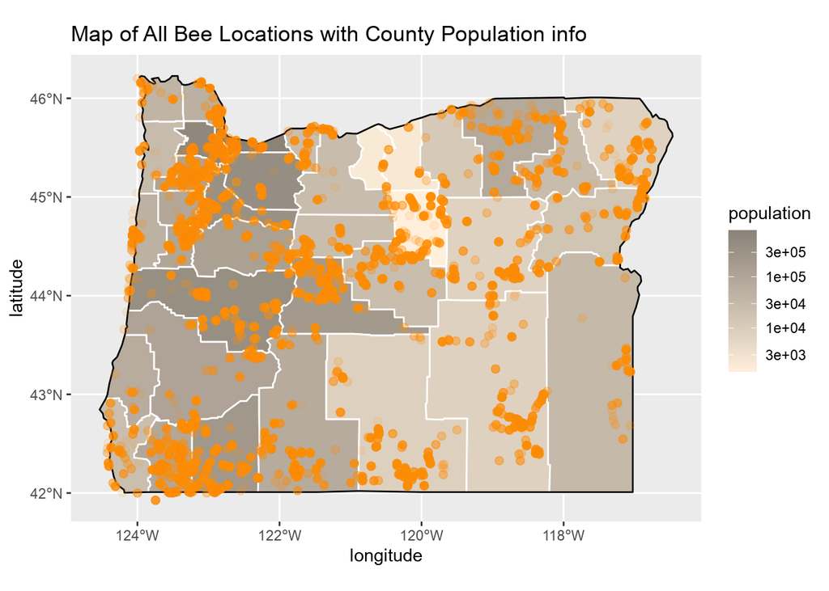

```r
all_species_data <- oba_2018_2019 %>%
  filter((decimalLongitude < -116) & (decimalLatitude < 46.5)) %>%
  select(x = decimalLongitude, y = decimalLatitude)

all_species_spatial <- st_as_sf(all_species_data, coords = c("x", "y"), crs = "WGS84")

p_title <- "Map of All Bee Locations with County Population info"
p <- ggplot() +
  geom_polygon(
    data = or_map_county_df, fill = "lightgray", color = "white",
    aes(x = longitude, y = latitude, group = county_name)
  ) +
  geom_polygon(
    data = or_map_with_population_df,
    aes(x = longitude, y = latitude, fill = population, group = county_name), color = "white"
  ) +
  scale_fill_gradient(trans = "log10", low = "antiquewhite1", high = "antiquewhite4") +
  geom_polygon(
    data = or_map_base_df, fill = NA, color = "black",
    aes(x = longitude, y = latitude, group = state_name)
  ) +
  geom_sf(data = all_species_spatial, color = "darkorange", alpha = 0.1, size = 2) +
  # geom_segment(aes(x = -118.4, y = 42.3, xend = -117.21, yend = 42.3), linewidth = 4) +
  # annotate("text", x = -117.8, y = 42.43, label = "100 km", size = 4) +
  # theme(plot.title = element_text(hjust = 0.5)) +
  ggtitle(p_title)
p
```

```r
ggsave(glue("plots/{p_title}.png"), dpi = 300, plot = p)
```